# Mine the Gap: Targeting High Risk Patients for Care Coordination & Social Support Services

[figure not shown]

## Problem

### From an at-risk patient's perspective, where are the gaps in care?

### Ultimately, where are the opportunities for improved system management for most at-risk enrollees?

## Goal

Let's ask further questions to better define what we hope to achieve.

#### Exploratory Analysis

> What factors are associated with poor and good health status?

> Are there any general patterns in comorbidity?

> What is the impact of pain on physical and mental quality of living?

> What is the relationship between mental health and presence of multiple chronic conditions?

> Regional Differences?

#### Cohort Analysis

> Among Medicare enrollees, which patients are among the most at-risk?

> What are there corresponding demographic and outcomes profiles on total health dimensions? (Heuristic Model)

> How does an individual enrollee's profile compare to Medicaid population? (Radar Chart)

## Data Preparation

#### Raw data from hosonline.org:

```python
!head -n 1 source_data/C16B_PUF.txt
```

[output not shown]

#### Intermediary parsing into csv:

```python
!head -n 1 source_data/C16B_PUF.csv
```

[output not shown]

#### The Final Dataset(s)

- Profile Dimensions
- Needs Dimensions
- Wellness Dimensions

Below we're going to join the needs and wellness domains, as it's our intended feature space.

```python
needs = pd.read_csv(os.path.join(DERIVED_DATA_PATH,'C16B_PUF_cleaned_needs.csv'), na_values=' ', index_col='ID')
wellness = pd.read_csv(os.path.join(DERIVED_DATA_PATH,'C16B_PUF_cleaned_wellness.csv'), na_values=' ', index_col='ID')

km_X = needs.join(wellness).dropna()
```

```python
print 'data retention post-drop: {:.2%} percent.'.format(float(len(km_X))/len(needs))
print '# records retention post-drop: {}'.format(len(km_X))
```

```
data retention post-drop: 69.73% percent.
# records retention post-drop: 211646
```

So that's not bad. Let's keep going with our cluster analysis by building our model.

## Build Model

```python
from sklearn.cluster import KMeans
from sklearn import metrics
from sklearn.metrics import pairwise_distances
```

**Sum of Squared Errors Definition:**

$$ SSE = \displaystyle\sum_{i=1}^{K}\sum_{x \in C_i} d(x, c_i)^2 $$

**Silhouette Coefficient Definition:**

$$ SC_{total} = 1/k \displaystyle\sum_{1}^{k}SC(C_{i}) $$

Now implementation...

```python
km_X = km_X.sample(n=10000, random_state=1)
```

```python
k_range = range(2,10)
```

Here we'll run "k_range" models with k clusters.

```python
%%timeit

SSEs = []
Sil_coefs = []

for k in k_range:
    #instantiate KMeans object
    km = KMeans(n_clusters=k, random_state=1)
    #fit model to training data
    km.fit(km_X)
    labels = km.labels_
    #store SC & SSE scores for each k run
    Sil_coefs.append(metrics.silhouette_score(km_X, labels, metric='euclidean'))
    SSEs.append(get_SSE(km_X, labels))
```

## Evaluate Model

```python
metrics.silhouette_score(km_X, labels, metric='euclidean')
```

[output not shown]

On interpreting the Average Silhouette Coefficient from [sckit-learn.org](http://scikit-learn.org/stable/auto_examples/cluster/plot_kmeans_silhouette_analysis.html):

> Silhoette coefficients (as these values are referred to as) near +1 indicate that the sample is far away from the neighboring clusters. A value of 0 indicates that the sample is on or very close to the decision boundary between two neighboring clusters and negative values indicate that those samples might have been assigned to the wrong cluster.

[output not shown]

[figure not shown]

```python
fig, (ax1, ax2) = plt.subplots(1,2, figsize=(15,5), sharex=True)
ax1.plot(k_range, Sil_coefs)
ax1.set_xlabel('number of clusters')
ax1.set_ylabel('silhouette coefficient')

# plot here on ax2
ax2.plot(k_range, SSEs)
ax2.set_xlabel('number of clusters')
ax2.set_ylabel('SSE');
```

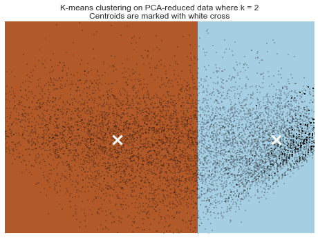

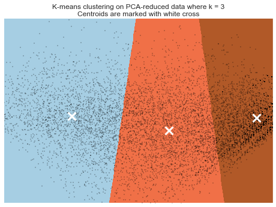

```python
# Visualize the results on PCA-reduced data
from sklearn.decomposition import PCA

reduced_data = PCA(n_components=2).fit_transform(km_X)

ax1 = show_kmeans_plot(1, 2, kmeans, reduced_data)
ax2 = show_kmeans_plot(2, 3, kmeans, reduced_data)
```

To keep track of beneficiary segment membership I've just made a little key for later analysis. Each record included in clustering (aka was not na/dropped) corresponds to a k=2 cluster and a k=3 cluster.

```python
ID_to_kmsegment.head(2)
```

|  | segment_k_2 | segment_k_3 |
| --- | --- | --- |
| C01000060 | 0 | 0 |
| C01000361 | 1 | 1 |

## Segment Profile Analysis

```python
profile = pd.read_csv(os.path.join(DERIVED_DATA_PATH,'C16B_PUF_cleaned_profile.csv'), na_values=' ', index_col='ID')
profile_seg = pd.concat([profile, ID_to_kmsegment], axis=1, join='inner')
profile_seg.head(1)
```

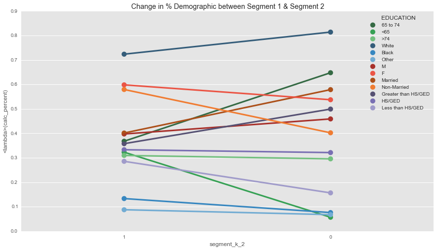

```python
fig = plt.subplots(1,1, sharey=True, figsize=(15,8))

sns.pointplot(estimator=sum_function, x='segment_k_2', y='calc_percent', hue='AGE', data=profile_seg, palette="Greens_d").set_title('Change in % Demographic between Segment 1 & Segment 2');
sns.pointplot(estimator=sum_function, x='segment_k_2', y='calc_percent', hue='RACE', data=profile_seg, palette="Blues_d");
sns.pointplot(estimator=sum_function, x='segment_k_2', y='calc_percent', hue='GENDER', data=profile_seg, palette="Reds_d");
sns.pointplot(estimator=sum_function, x='segment_k_2', y='calc_percent', hue='MARITALSTAT', data=profile_seg, palette="Oranges_d");
sns.pointplot(estimator=sum_function, x='segment_k_2', y='calc_percent', hue='EDUCATION', data=profile_seg, palette="Purples_d");
```

```python
#for each column of interest
demog_cols = list(profile_seg.columns[:5])
draw_table(demog_cols)
```

| Demographic Characteristics | X^2 (p) | Segment 1(%) | Segment 0 (%) | Odds Ratio |
| --- | --- | --- | --- | --- |
| AGE | 30235.0 (0.00E+00) |  |  |  |
| 65 to 74 |  | 36.8 | 64.9 | 0.3 |
| <65 |  | 32.5 | 5.5 | 8.3 |
| >74 |  | 30.7 | 29.7 | 1.1 |
| RACE | 2787.5 (0.00E+00) |  |  |  |
| Black |  | 13.6 | 7.7 | 1.9 |
| Other |  | 8.5 | 6.3 | 1.4 |
| White |  | 71.8 | 82.1 | 0.6 |
| GENDER | 608.1 (2.84E-134) |  |  |  |
| F |  | 60.1 | 54.7 | 1.2 |
| M |  | 39.5 | 44.9 | 0.8 |
| MARITALSTAT | 6533.9 (0.00E+00) |  |  |  |
| Married |  | 39.9 | 57.7 | 0.5 |
| Non-Married |  | 57.9 | 40.3 | 2.0 |
| EDUCATION | 7840.6 (0.00E+00) |  |  |  |
| Greater than HS/GED |  | 34.4 | 49.9 | 0.5 |
| HS/GED |  | 33.4 | 32.7 | 1.0 |
| Less than HS/GED |  | 29.4 | 15.1 | 2.3 |

```python
#@Ceslee:Explore why 8 times more <65
pd.pivot_table(profile_seg, index='AGE')
```

[output not shown]

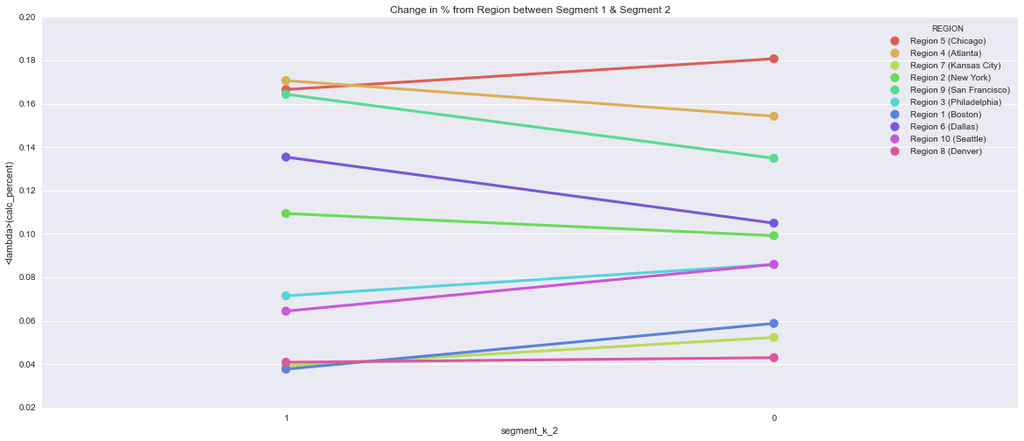

```python
fig_region = plt.subplots(1,1, figsize=(20,8))
sns.pointplot(estimator=sum_function, x='segment_k_2', y='calc_percent', hue='REGION', data=profile_seg, palette="hls").set_title('Change in % from Region between Segment 1 & Segment 2');
```

```python
#for each column of interest
region_cols = ['REGION']
draw_table(region_cols)
```

| Demographic Characteristics | X^2 (p) | Segment 1(%) | Segment 0 (%) | Odds Ratio |
| --- | --- | --- | --- | --- |
| REGION | 2110.7 (0.00E+00) |  |  |  |
| Region 1 (Boston) |  | 4.1 | 6.0 | 0.7 |
| Region 10 (Seattle) |  | 6.8 | 8.4 | 0.8 |
| Region 2 (New York) |  | 11.1 | 9.4 | 1.2 |
| Region 3 (Philadelphia) |  | 7.3 | 8.7 | 0.8 |
| Region 4 (Atlanta) |  | 16.9 | 15.2 | 1.1 |
| Region 5 (Chicago) |  | 16.1 | 18.6 | 0.8 |
| Region 6 (Dallas) |  | 14.7 | 10.6 | 1.4 |
| Region 7 (Kansas City) |  | 3.9 | 5.3 | 0.7 |
| Region 8 (Denver) |  | 3.9 | 4.4 | 0.9 |
| Region 9 (San Francisco) |  | 15.2 | 13.4 | 1.2 |

```
	 	 # of Chronic Conditions by Segment
```

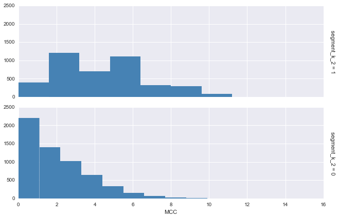

```python
print '\t \t # of Chronic Conditions by Segment'
g = sns.FacetGrid(profile_seg, aspect=3, row='segment_k_2', margin_titles=True);
g.map(plt.hist, 'MCC', color="steelblue", lw=0);
```

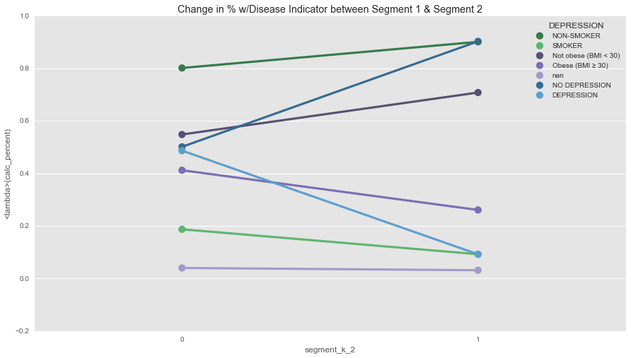

```python
fig2 = plt.subplots(1,1, sharey=True, figsize=(15,8))

profile_seg.replace({
        'SMOKER':{0:'NON-SMOKER', 1:'SMOKER'},
        'DEPRESSION':{0:'NO DEPRESSION',1:'DEPRESSION'},
        'AT-RISK':{False:'NOT AT-RISK', True:'AT-RISK'},
        'CC-NEED':{False:'NO CC-NEEDED', True:'CC-NEEDED'}
    }, inplace=True)

profile_seg['OBESE'] = profile_seg['OBESE'].map(lambda x: str(x).decode('utf-8').strip())

sns.pointplot(estimator=sum_function, x='segment_k_2', y='calc_percent', hue='SMOKER', data=profile_seg, palette="Greens_d").set_title('Change in % w/Disease Indicator between Segment 1 & Segment 2');
sns.pointplot(estimator=sum_function, x='segment_k_2', y='calc_percent', hue='OBESE', data=profile_seg, palette="Purples_d");
sns.pointplot(estimator=sum_function, x='segment_k_2', y='calc_percent', hue='DEPRESSION', data=profile_seg, palette="Blues_d");
```

```python
#for each column of interest
disease_indicators_cols = list(profile_seg.columns[7:9])
draw_table(disease_indicators_cols)
```

| Demographic Characteristics | X^2 (p) | Segment 1(%) | Segment 0 (%) | Odds Ratio |
| --- | --- | --- | --- | --- |
| OBESE | 5637.8 (0.00E+00) |  |  |  |
| Not obese (BMI < 30) |  | 54.8 | 70.8 | 0.5 |
| Obese (BMI > 30) |  | 41.2 | 26.1 | 2.0 |
| SMOKER | 4107.2 (0.00E+00) |  |  |  |
| 0.0 |  | 80.1 | 90.1 | 0.4 |
| 1.0 |  | 18.7 | 9.2 | 2.3 |

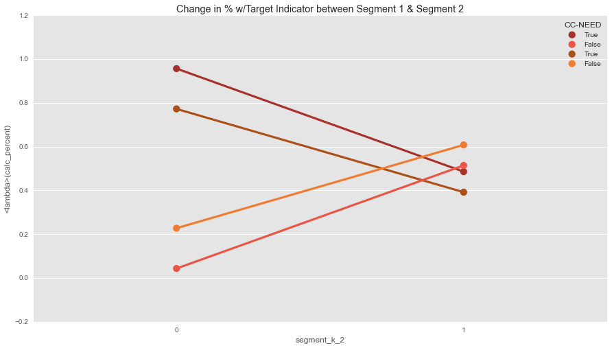

```python
fig3 = plt.subplots(1,1, sharey=True, figsize=(15,8))
sns.pointplot(estimator=sum_function, x='segment_k_2', y='calc_percent', hue='AT-RISK', data=profile_seg, palette="Reds_d").set_title('Change in % w/Target Indicator between Segment 1 & Segment 2');
sns.pointplot(estimator=sum_function, x='segment_k_2', y='calc_percent', hue='CC-NEED', data=profile_seg, palette="Oranges_d");
```

```python
#for each column of interest
targets_cols = list(profile_seg.columns[11:13])
draw_table(targets_cols)
```

| Demographic Characteristics | X^2 (p) | Segment 1(%) | Segment 0 (%) | Odds Ratio |
| --- | --- | --- | --- | --- |
| AT-RISK | 51497.8 (0.00E+00) |  |  |  |
| AT-RISK |  | 95.7 | 48.6 | 23.4 |
| NOT AT-RISK |  | 4.3 | 51.4 | 0.0 |
| CC-NEED | 29717.6 (0.00E+00) |  |  |  |
| CC-NEEDED |  | 77.2 | 39.2 | 5.3 |
| NO CC-NEEDED |  | 22.8 | 60.8 | 0.2 |

## Segment Factor Analysis

```python
needs_wellness_seg = pd.concat([km_X, ID_to_kmsegment], axis=1, join='inner')
needs_wellness_seg.head(1)
```

| ID | FELTNP | FELTSD | PNIACT | SCLACT | DIFBTH | DIFDRS | DIFEAT | DIFCHR | DIFWLK | DIFTOL | ... | Bodily Pain | General Health | Vitality | Social Functioning | Physical Functioning | Role Physical | Role Emotional | Mental Health | segment_k_2 | segment_k_3 |
| --- | --- | --- | --- | --- | --- | --- | --- | --- | --- | --- | --- | --- | --- | --- | --- | --- | --- | --- | --- | --- | --- |
| C01000060 | 0 | 0 | 1 | 1 | 0 | 0 | 0 | 1 | 1 | 0 | ... | 3 | 4 | 5 | 1 | 2 | 4 | 3 | 2.5 | 0 | 0 |

1 rows × 27 columns

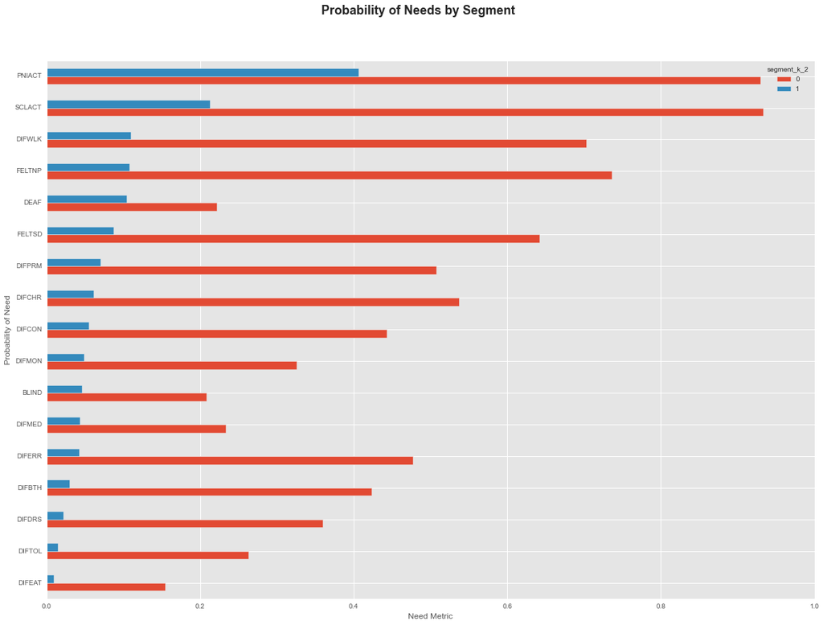

```python
#prob of needs in sort order vertical
fig = plt.figure()
fig.suptitle('Probability of Needs by Segment', fontsize=18, fontweight='bold')

ax = fig.add_subplot(111)
ax.set_xlabel('Need Metric')
ax.set_ylabel('Probability of Need')

needs_cols = list(needs_wellness_seg.columns[0:17])  + ['segment_k_2']
needs_seg = needs_wellness_seg[needs_cols]
chart = pd.pivot_table(needs_seg, index='segment_k_2').transpose().sort(columns=[1]).plot(kind='barh', ax=ax, figsize=(20,14))
```

```python
#logistic regression/naive bayes + decision trees
#benchmark at better than target.mean
features_array = needs_seg[needs_seg.columns[:-1]].values
target = needs_seg[needs_seg.columns[-1]].values

#train/test split
from sklearn.cross_validation import train_test_split

features_train, features_test, target_train, target_test = train_test_split(
    features_array, target, test_size=0.01, random_state=0)

#build model
from sklearn.linear_model import LogisticRegression

lr = LogisticRegression(penalty='l1')
lr.fit(features_train, target_train)
```

```
LogisticRegression(C=1.0, class_weight=None, dual=False, fit_intercept=True,
          intercept_scaling=1, penalty='l1', random_state=None, tol=0.0001)
```

```python
#test model
target_predicted = lr.predict(features_test)

from sklearn.metrics import accuracy_score

print 'Logistic Reg Model: {:.3f}'.format(accuracy_score(target_test, target_predicted))

print 'Baseline Model: {:.3f}'.format(target.mean())
```

```
Logistic Reg Model: 0.892
Baseline Model: 0.597
```

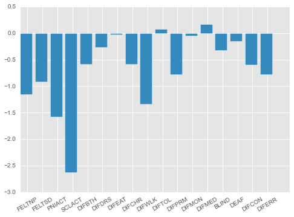

```python
feature_names = needs_seg.columns[:-1].values
feature_names
x = np.arange(len(feature_names))
plt.bar(x, lr.coef_.ravel())
_ = plt.xticks(x + 0.5, feature_names, rotation=30)
```

```python
pd.DataFrame({'Coefficient':lr.coef_.ravel()}, index=feature_names).sort('Coefficient')
```

|  | Coefficient |
| --- | --- |
| SCLACT | -2.621310 |
| PNIACT | -1.582304 |
| DIFWLK | -1.342296 |
| FELTNP | -1.150241 |
| FELTSD | -0.913631 |
| DIFERR | -0.781570 |
| DIFPRM | -0.778829 |
| DIFCON | -0.594639 |
| DIFBTH | -0.584661 |
| DIFCHR | -0.583924 |
| BLIND | -0.324621 |
| DIFDRS | -0.266262 |
| DEAF | -0.152477 |
| DIFMON | -0.052611 |
| DIFEAT | -0.028017 |
| DIFTOL | 0.077513 |
| DIFMED | 0.170691 |

```python
%%html
<!-- inspired by http://nbremer.blogspot.nl/2013/09/making-d3-radar-chart-look-bit-better.html -->
<head>
    <meta http-equiv="Content-Type" content="text/html;charset=utf-8"/>
    <title>Radar chart</title>
    <script src="http://d3js.org/d3.v3.min.js"></script>
    <script src="radar-chart/RadarChart.js"></script>
    <style>
        body {
            overflow: hidden;
            margin: 0;
            font-size: 14px;
            font-family: "Helvetica Neue", Helvetica;
        }
        #chart {
            position: floating;
            top: 50px;
            left: 100px;
        }
    </style>
</head>
<body>
    <div id="body">
        <div id="chart"></div>
    </div>
    <script src="radar-chart/script.js"></script>
</body>
```

```python
wellness_seg.head()
```

| ID | General Health | Vitality | Social Functioning | Physical Functioning | Role Physical | Role Emotional | Mental Health | segment_k_2 |
| --- | --- | --- | --- | --- | --- | --- | --- | --- |
| C01000060 | 4 | 5 | 1 | 2.0 | 4.0 | 3.0 | 2.5 | 0 |
| C01000361 | 3 | 4 | 0 | 0.5 | 1.5 | 1.0 | 1.0 | 1 |
| C01000542 | 3 | 6 | 1 | 2.0 | 2.5 | 1.0 | 1.0 | 0 |
| C01000633 | 5 | 6 | 3 | 0.0 | 5.0 | 5.0 | 4.0 | 0 |
| C01000819 | 4 | 4 | 0 | 1.5 | 3.0 | 2.5 | 2.0 | 0 |

```python
#logistic regression/naive bayes + decision trees
#benchmark at better than target.mean
features_array = wellness_seg[wellness_seg.columns[:-1]].values
target = wellness_seg[wellness_seg.columns[-1]].values

#train/test split
from sklearn.cross_validation import train_test_split

features_train, features_test, target_train, target_test = train_test_split(
    features_array, target, test_size=0.01, random_state=0)

#build model
from sklearn.linear_model import LogisticRegression

lr = LogisticRegression(penalty='l1')
lr.fit(features_train, target_train)
```

```
LogisticRegression(C=1.0, class_weight=None, dual=False, fit_intercept=True,
          intercept_scaling=1, penalty='l1', random_state=None, tol=0.0001)
```

```python
#test model
target_predicted = lr.predict(features_test)

from sklearn.metrics import accuracy_score

print 'Logistic Reg Model: {:.3f}'.format(accuracy_score(target_test, target_predicted))

print 'Baseline Model: {:.3f}'.format(target.mean())
```

```
Logistic Reg Model: 0.966
Baseline Model: 0.597
```

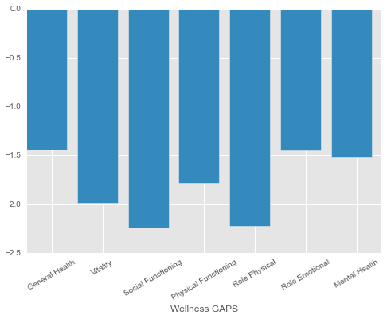

```python
feature_names = wellness_seg.columns[:-1].values
feature_names
x = np.arange(len(feature_names))
plt.bar(x, lr.coef_.ravel())
_ = plt.xticks(x + 0.5, feature_names, rotation=30)

plt.xlabel('Wellness GAPS')
```

```python
pd.DataFrame({'Coefficient':lr.coef_.ravel()}, index=feature_names).sort('Coefficient')
```

|  | Coefficient |
| --- | --- |
| Social Functioning | -2.238198 |
| Role Physical | -2.223983 |
| Vitality | -1.987211 |
| Physical Functioning | -1.785459 |
| Mental Health | -1.512968 |
| Role Emotional | -1.448073 |
| General Health | -1.441979 |

## Final Model Evaluation

```python
#Plot AtRisk, CC-Need, segment_k_3 against health factors to evaluate
#precision for the three? how many true, true for AtR-seg, CC-seg

#1. SC and SSE on other class labels
X = km_X

#get index from X, retrieve AtR from Profile
AtR_labels = profile.loc[(km_X.index), 'AT-RISK'].values
CC_Need_labels = profile.loc[(km_X.index), 'CC-NEED'].values

def get_scores(X, labels):
    #store SC & SSE scores for each k run
    Sil_coef = metrics.silhouette_score(X, labels, metric='euclidean')
    SSE = get_SSE(X, labels)
    return SSE, Sil_coef

AtR_SSE, AtR_Sil_coef = get_scores(X, AtR_labels)
CC_Need_SSE, CC_Need_Sil_coef = get_scores(X, CC_Need_labels)

model_labels = ['At-Risk', 'CC-Need', 'KMeansMicroTarget']
model_Sil_Coefs = [AtR_Sil_coef, CC_Need_Sil_coef, Sil_coefs[0]]
model_SSEs = [AtR_SSE, CC_Need_SSE, SSEs[0]]


fig_compare, (ax1, ax2) = plt.subplots(1,2, figsize=(15,5), sharex=True)
ax1.bar(model_Sil_Coefs, model_labels)
ax1.set_xlabel('Model/Metric')
ax1.set_ylabel('silhouette coefficient')

# plot here on ax2
ax2.plot(SSEs, model_labels)
ax2.set_xlabel('Model/Metric')
ax2.set_ylabel('SSE');
```

[output not shown]

## Wrap-Up

# Future stuff:

> Predicting for new beneficiaries which segment they should be in. Learning more about why social activity is so common and thus an important feature in both segments. Breaking it down by disease types